# Case 3: TCGA analysis

Saskia van Asten

# Introduction

This document contains the code used to analyze TCGA RNA-seq data for case study 3 as discussed in the manuscript *VIBE : An R-package for advanced RNA-seq data visualization for therapeutic targeting and disease stratification* by Khatri *et al*. The first part explains how to download the data, the second how the VIBE package functions are used to create the visualizations.

# Part1: download TCGA RNA-seq data

## install/load libraries

Install the libraries [TCGAbiolinks](https://bioconductor.org/packages/release/bioc/html/TCGAbiolinks.html) and [SummarizedExperiment](https://bioconductor.org/packages/release/bioc/html/SummarizedExperiment.html%22SummarizedExperiment%20on%20bioconductor%22) from Bioconductor and dplyr from CRAN.

```r
if (!require("BiocManager", quietly = TRUE))
    install.packages("BiocManager")

BiocManager::install("TCGAbiolinks")
BiocManager::install("SummarizedExperiment")
install.packages("dplyr")
```

Once installed, restart R and load the libraries.

```r
library(TCGAbiolinks)
library(SummarizedExperiment)
library(dplyr)
```

## download selected TCGA data

Set up the query to select what data to download. We selected 15 TCGA projects and both `Primary Tumor` and `Solid Tissue Normal` samples.

```r
# list projects of interest
tcga_projects <- list("TCGA-BLCA", "TCGA-BRCA", "TCGA-CESC", "TCGA-COAD", "TCGA-ESCA", "TCGA-HNSC", "TCGA-KIRC", "TCGA-LUAD", "TCGA-LUSC", "TCGA-OV", "TCGA-PAAD", "TCGA-READ", "TCGA-SKCM", "TCGA-STAD", "TCGA-UCEC")

# query to select which files to download
query <- GDCquery(
  project = tcga_projects,
  data.category = "Transcriptome Profiling",
  data.type = "Gene Expression Quantification",
  workflow.type = "STAR - Counts",
  sample.type = c("Primary Tumor", "Solid Tissue Normal")
)
```

Download the data as selected using the query above.

```r
# set path to save the downloaded data to
path_tcga <- "~/downloads/tcgabiolink/" #** change path for your system

# download (one tsv file per sample)
GDCdownload(query = query,
            directory = path_tcga,
            files.per.chunk = 100)
```

## combine tsv files as rdata

The data is downloaded as one tsv file per sample, but we want everything together in one object. Use `GDCprepare()` to create one object and save as an rdata object.

```r
# create one rdata file for all queried samples
exp <- GDCprepare(
  query = query,
  save = TRUE,
  directory = path_tcga,
  save.filename = "TCGAbiolink_primarytumor.rda"
)
```

## load rdata

```r
load("~/download/TCGAbiolink/TCGAbiolink_primarytumor.rda") #** update to your file location
```

## create table from rdata object

The rdata object stores both metadata and RNA-seq data. To be able to plot the data we’ll need to extract the relevant data and combine them into a dataframe (table).

```r
# select metadata to include
# colnames(data@colData)
dim(data@colData)
```

```
## [1] 6928  690
```

```r
df_meta <- data@colData[c("barcode", "sample", "patient", "sample_type", "tissue_type", "gender","project_id", "primary_site")]
df_meta$primary_site <- as.character(df_meta$primary_site)
df_meta <- as.data.frame(df_meta)
```

```r
# extract tpm_unstrand assay data
tpm <- data@assays@data@listData$tpm_unstrand
colnames(tpm) <- df_meta$barcode
dim(tpm)
```

```
## [1] 60660  6928
```

```r
rows <- as.data.frame(rowRanges(data))
df_tpm <- cbind(rows[,c("gene_name", "gene_id", "gene_type")], as.data.frame(tpm))
```

We’re only interested in a limited set of genes, so we can select data from only those genes so that we have a smaller table to work with.

```r
target1 = "TYRP1"
target2 = "CD3D"

other_genes = c("CD3E", "CD3G")

gene_panel = unique(c(target1, target2, other_genes))
```

Contain only genes of interest and merge tpm data with metadata.

```r
df <- dplyr::filter(df_tpm, gene_name %in% gene_panel) |>
  tidyr::pivot_longer(cols = starts_with("TCGA"),
                      names_to = "barcode",
                      values_to = "tpm") |>
  dplyr::mutate(log2_tpm = log2(tpm+1)) |>
  dplyr::left_join(df_meta, by = "barcode")
```

Save as csv file.

```r
write.csv(df, "tcga_expression_data.csv", row.names = FALSE)
```

# Part 2: using VIBE to visualize TCGA data

## Load libraries

This workflow assumes you have already installed the VIBE and tidyverse packages.

```r
library(vibe)
library(tidyverse)
```

## Load data

```r
df <- read.csv(df, "tcga_expression_data.csv")
```

## VIBE harmonization

Set a dataset name so we can reuse it for all plots.

```r
# set a dataset name
dataset_name = "TCGA RNA-seq from TCGABiolink"
```

Run the harmonization function to create a dataframe combatible with the VIBE plotting functions. In addition, create a new column that contains the tissue type.

```r
df_harmonized <- vibe::harmonize_df(
  df = df, col_patientid = "patient",
  col_sampleid = "barcode",
  col_indication = "project_id",
  col_symbol = "gene_name",
  col_value = "log2_tpm",
  unit = "tpm+1",
  keep_extra_cols = c("gender", "primary_site", "tissue_type")
  ) %>%
  dplyr::mutate(
    project_tissuetype = paste(stringr::str_remove_all(indication, "TCGA\\-"), stringr::str_extract(tissue_type, pattern = "^.{1}"), sep = "_")
         )
```

```
## Returning dataframe with the following columns:indication,symbol,value,treatment,patientid,sampleid,gender,primary_site,tissue_type,intr,unit
```

```r
head(df_harmonized)
```

```
## # A tibble: 6 × 12
##   indication symbol  value treatment patientid    sampleid   gender primary_site
##   <chr>      <chr>   <dbl> <chr>     <chr>        <chr>      <chr>  <chr>
## 1 TCGA-BLCA  TYRP1  2.61   <NA>      TCGA-CU-A3KJ TCGA-CU-A… male   Bladder
## 2 TCGA-BLCA  TYRP1  0.154  <NA>      TCGA-K4-A3WU TCGA-K4-A… male   Bladder
## 3 TCGA-BLCA  TYRP1  1.23   <NA>      TCGA-DK-A3IU TCGA-DK-A… male   Bladder
## 4 TCGA-BLCA  TYRP1  0.0389 <NA>      TCGA-GV-A40G TCGA-GV-A… male   Bladder
## 5 TCGA-BLCA  TYRP1  0.311  <NA>      TCGA-DK-A3IN TCGA-DK-A… male   Bladder
## 6 TCGA-BLCA  TYRP1  3.28   <NA>      TCGA-SY-A9G0 TCGA-SY-A… male   Bladder
## # ℹ 4 more variables: tissue_type <chr>, intr <fct>, unit <chr>,
## #   project_tissuetype <chr>
```

For several plots we only want to show tumor and not normal samples. To be able to select only the tumor samples for plotting, we’re assigning the tumor groups to `tumor_groups`.

```r
# to ensure separation tumor and normal tissues
tumor_groups <- unique(dplyr::filter(df_harmonized, tissue_type == "Tumor")$project_tissuetype)

print(tumor_groups)
```

```
##  [1] "BLCA_T" "BRCA_T" "CESC_T" "COAD_T" "ESCA_T" "HNSC_T" "KIRC_T" "LUAD_T"
##  [9] "LUSC_T" "OV_T"   "PAAD_T" "READ_T" "SKCM_T" "STAD_T" "UCEC_T"
```

## Plots

### Figure 4D

Expression of TYRP1 across tumor samples from selected TCGA projects, visualized using VIBE’s plot_expression_box function.

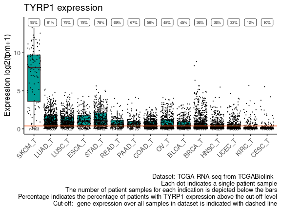

```r
p_box_target1 <- vibe::plot_expression_box(df = df_harmonized, gene = target1, method = "median", order = "T", dataset = dataset_name, grouping_var = "project_tissuetype", plot_groups = tumor_groups)

p_box_target1
```

### Figure 4E

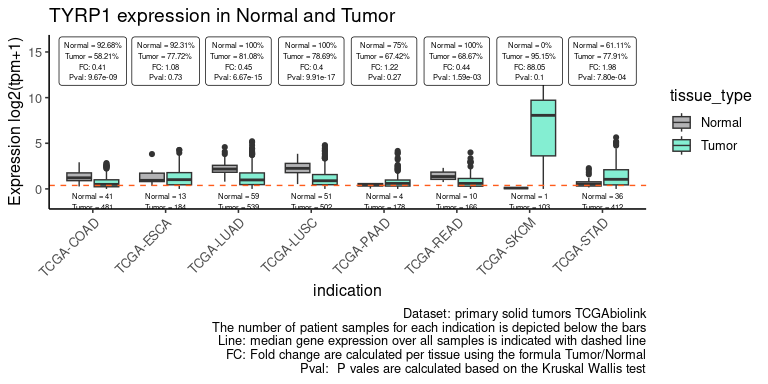

```r
p_box_tvn_target1 <- vibe::plot_expression_box_split(df = df_harmonized, gene = target1, threshold_method = "median", dataset = "primary solid tumors TCGAbiolink", grouping_var = "indication", splitting_var = "tissue_type", plot_groups = c("TCGA-SKCM", "TCGA-LUAD", "TCGA-LUSC", "TCGA-ESCA", "TCGA-STAD", "TCGA-READ", "TCGA-PAAD", "TCGA-COAD"))

p_box_tvn_target1
```

### Figure S1

The scatterplots show the distribution of samples in four quadrants based on the median expression level of *TYRP1* and *CD3D*. The samples are colored based on the expression level of *CD3E*. expression levels are reported in log2(TPM+1). The scatterplot also reports the spearman correlation and P-value along with the percentage of samples in the Q2 quadrant.

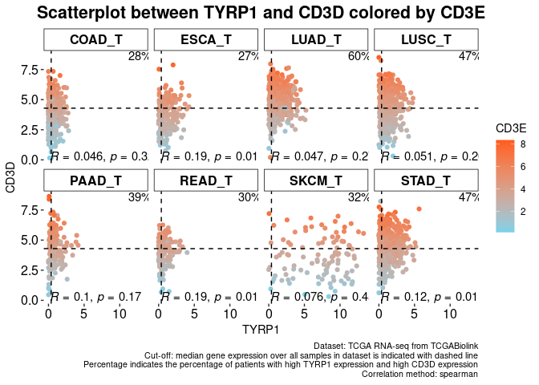

```r
p_scatter <- vibe::plot_expression_scatter(df_harmonized, target1 = target1, target2 = target2, target3 = gene_panel[3], QOI = "Q2", cor_method = "spearman", threshold_method = "median", dataset = dataset_name, grouping_var = "project_tissuetype", plot_groups = c("SKCM_T", "LUAD_T", "LUSC_T", "ESCA_T", "STAD_T", "READ_T", "PAAD_T", "COAD_T"))
p_scatter
```